# GES 001 演習6

#### 地域の `iso2c` コード

country には、国と地域両方が入っています。地域の iso2c は以下のものです。

```r
REGION <- c("1A", "1W", "4E", "7E", "8S", "B8", "EU", "F1", "OE", "S1",
"S2", "S3", "S4", "T2", "T3", "T4", "T5", "T6", "T7", "V1", "V2",
"V3", "V4", "XC", "XD", "XE", "XF", "XG", "XH", "XI", "XJ", "XL",
"XM", "XN", "XO", "XP", "XQ", "XT", "XU", "XY", "Z4", "Z7", "ZF",
"ZG", "ZH", "ZI", "ZJ", "ZQ", "ZT")
```

地域のリストを表示

```r
df_environment |> filter(iso2c %in% REGION) |> distinct(country, iso2c)
```

[output not shown]

国名とその地域・所得レベルを表示

```r
df_environment |> filter(!(iso2c %in% REGION)) |> distinct(country, iso2c,region,income)
```

[output not shown]

#### 変数の選択（selecting）

```r
df_env <- df_environment |>
  select(country, iso2c, year, co2pcap, forest,
         renewable, fossil, nuclea, region, income)
df_env
```

| country | iso2c | year | co2pcap | forest | renewable | fossil | nuclea | region | income |
| --- | --- | --- | --- | --- | --- | --- | --- | --- | --- |
| Afghanistan | AF | 2014 | 0.28369240 | 1.8527820 | 85.3235490 | NA | NA | South Asia | Low income |
| Afghanistan | AF | 1971 | NA | NA | NA | NA | NA | South Asia | Low income |
| Afghanistan | AF | 2006 | 0.08975691 | 1.8527820 | 70.7557503 | NA | NA | South Asia | Low income |
| Afghanistan | AF | 2013 | 0.29808781 | 1.8527820 | 78.6364081 | NA | NA | South Asia | Low income |
| Afghanistan | AF | 1995 | 0.08878116 | 1.8527820 | 69.0370370 | NA | NA | South Asia | Low income |
| Afghanistan | AF | 2005 | 0.08036113 | 1.8527820 | 74.0618102 | NA | NA | South Asia | Low income |
| Afghanistan | AF | 1997 | 0.07555870 | 1.8527820 | 72.3880597 | NA | NA | South Asia | Low income |
| Afghanistan | AF | 1998 | 0.07126970 | 1.8527820 | 74.4360902 | NA | NA | South Asia | Low income |
| Afghanistan | AF | 1999 | 0.05824684 | 1.8527820 | 73.7226277 | NA | NA | South Asia | Low income |
| Afghanistan | AF | 1996 | 0.08226652 | 1.8527820 | 70.3703704 | NA | NA | South Asia | Low income |

[output cut: 990 more lines]

### 変数同士の相関関係: NA ではないところのみ選択

```r
df_env |> filter(!(iso2c %in% REGION)) |> # 地域以外（国のみ選択）
  drop_na(co2pcap, forest, renewable, fossil, nuclea) |>
  select(co2pcap, forest, renewable, fossil, nuclea) |> cor()
```

```
             co2pcap     forest  renewable     fossil     nuclea
co2pcap    1.0000000 -0.1832374 -0.4138267  0.3220169  0.1369711
forest    -0.1832374  1.0000000  0.3683177 -0.4234481  0.1131410
renewable -0.4138267  0.3683177  1.0000000 -0.8784240 -0.1851655
fossil     0.3220169 -0.4234481 -0.8784240  1.0000000 -0.2354258
nuclea     0.1369711  0.1131410 -0.1851655 -0.2354258  1.0000000
```

値の正負：正の相関・負の相関、1に近いと強い正の相関、-1に近いと強い負の相関

相関係数：散布図の近似（回帰）直線の傾きが正なら正、負なら負、直線に近い程、1 または-1 に近い

## ファイルリンク

基本的には、PositCloud（https://posit.cloud/）を使って実習

R Notebook のソースファイル（Rmd）を取得方法

- **Rmd のリンクをクリックし Raw の横の Copy a raw file からコピー、新規 RMarkdown ファイルを PositCloud または RStudio のプロジェクト内に作成しペースト**

## 演習

以下の指標の中から、二つを選択して、データの概要（description）を記録し、データを WDI で取得し、以下の分析をする。

1. 各年毎のデータの数の棒グラフ
2. 国または地域を選択
3. それぞれの経年変化を表す折れ線グラフ
   1. 日本
   2. 選択した国または地域
4. 二つのデータの散布図-必要に応じて log10 スケールを用いる
   1. すべての値の散布図
   2. NA ではない値の散布図、近似（回帰）直線を表示
   3. 地域を除き国のみの散布図、近似（回帰）直線を表示
   4. 最近の年を選択し、地域を除き国のもの散布図、近似（回帰）直線を表示

それぞれについて考察（気づいたこと、疑問など）を記す

### 確認作業

- Preview で確認。
- Web Browser で、w5_c123456.nb.html など、R Notebook を見て確認。
- もし、問題があれば、Run ボタンの右の三角から、Run All を選択し、エラーがでないか確認。
- 最初にもどる。

### 途中でのエラー

- 入力したときには、例を参照して、スペルなどを確認してください。全角になっていると問題がおきます。() がペアでマッチしているか、確認してください。
- 引用符が入っていなかったり、== のところが、= だったり、いろいろな可能性があります。Error message を読むこともたいせつです。エラーがでた、Code Chunk と、Error message を、ChatGPT や、Google Bard, Google Search に入れると、解決方法を教えてくれることもあります。
- File not found の、エラーがでたときには、上から順に、Run （Code Chunk の右上の三角印を押して実行）してみてください。または、エラーが出たところに、カーソルを置き、上の、Run ボタンの右の三角から、Run All Chunks Above を選択すると、そこまでのすべての Code Chunk を実行してくれます。
- 上の方法でうまくいかないときは、data フォルダに、データ（***.csv）が入っているかを確認、なければ、data フォルダがあることを確認して、最初のデータ読み込みのところを実行してみてください。
- 実行できていても、結果が見えないこともあります。そのときは、Code Chunk の下にある、山二つの記号を押してみてください。これは、結果を表示、非表示にします。それが原因で隠れている場合があります。

## データ

### データ情報

- データ１：一人当たりの二酸化炭素排出量 (CO2 emissions (metric tons per capita))、“EN.ATM.CO2E.PC”、co2pcap [[Link](https://data.worldbank.org/indicator/EN.ATM.CO2E.PC)]
- 概要：Carbon dioxide emissions are those stemming from the burning of fossil fuels and the manufacture of cement. They include carbon dioxide produced during consumption of solid, liquid, and gas fuels and gas flaring.
- データ２：森林面積（％）(Forest area (% of land area))、“AG.LND.FRST.ZS”、forest [[Link](https://data.worldbank.org/indicator/AG.LND.FRST.ZS)]
- 概要：Forest area is land under natural or planted stands of trees of at least 5 meters in situ, whether productive or not, and excludes tree stands in agricultural production systems (for example, in fruit plantations and agroforestry systems) and trees in urban parks and gardens.

### データの取得

#### 準備

```r
library(tidyverse)
library(WDI)
```

データのダウンロードと保存：コードと変数名を指定。

```r
df_w6eda <- WDI(indicator = c(co2pcap = "EN.ATM.CO2E.PC",
                              forest = "AG.LND.FRST.ZS"),
                extra = TRUE)
```

*２回目からは、data から読み込めるようにしておく ファイル (Rmd) の保存場所に data フォルダがあることを確認*

```r
write_csv(df_w6eda, "data/w6eda.csv")
```

```r
df_w6eda <- read_csv("data/w6eda.csv")
```

### データの確認

```r
df_w6eda
```

| country | iso2c | iso3c | year | status | lastupdated | co2pcap | forest | region | capital | longitude | latitude | income | lending |
| --- | --- | --- | --- | --- | --- | --- | --- | --- | --- | --- | --- | --- | --- |
| Afghanistan | AF | AFG | 2014 | NA | 2023-12-18 | 0.28369240 | 1.8527820 | South Asia | Kabul | 69.17610 | 34.52280 | Low income | IDA |
| Afghanistan | AF | AFG | 1971 | NA | 2023-12-18 | NA | NA | South Asia | Kabul | 69.17610 | 34.52280 | Low income | IDA |
| Afghanistan | AF | AFG | 2006 | NA | 2023-12-18 | 0.08975691 | 1.8527820 | South Asia | Kabul | 69.17610 | 34.52280 | Low income | IDA |
| Afghanistan | AF | AFG | 2013 | NA | 2023-12-18 | 0.29808781 | 1.8527820 | South Asia | Kabul | 69.17610 | 34.52280 | Low income | IDA |
| Afghanistan | AF | AFG | 1995 | NA | 2023-12-18 | 0.08878116 | 1.8527820 | South Asia | Kabul | 69.17610 | 34.52280 | Low income | IDA |
| Afghanistan | AF | AFG | 2005 | NA | 2023-12-18 | 0.08036113 | 1.8527820 | South Asia | Kabul | 69.17610 | 34.52280 | Low income | IDA |
| Afghanistan | AF | AFG | 1997 | NA | 2023-12-18 | 0.07555870 | 1.8527820 | South Asia | Kabul | 69.17610 | 34.52280 | Low income | IDA |
| Afghanistan | AF | AFG | 1998 | NA | 2023-12-18 | 0.07126970 | 1.8527820 | South Asia | Kabul | 69.17610 | 34.52280 | Low income | IDA |
| Afghanistan | AF | AFG | 1999 | NA | 2023-12-18 | 0.05824684 | 1.8527820 | South Asia | Kabul | 69.17610 | 34.52280 | Low income | IDA |
| Afghanistan | AF | AFG | 1996 | NA | 2023-12-18 | 0.08226652 | 1.8527820 | South Asia | Kabul | 69.17610 | 34.52280 | Low income | IDA |

[output cut: 990 more lines]

```r
str(df_w6eda)
```

```
spc_tbl_ [16,758 × 14] (S3: spec_tbl_df/tbl_df/tbl/data.frame)
 $ country    : chr [1:16758] "Afghanistan" "Afghanistan" "Afghanistan" "Afghanistan" ...
 $ iso2c      : chr [1:16758] "AF" "AF" "AF" "AF" ...
 $ iso3c      : chr [1:16758] "AFG" "AFG" "AFG" "AFG" ...
 $ year       : num [1:16758] 2014 1971 2006 2013 1995 ...
 $ status     : logi [1:16758] NA NA NA NA NA NA ...
 $ lastupdated: Date[1:16758], format: "2023-12-18" "2023-12-18" ...
 $ co2pcap    : num [1:16758] 0.2837 NA 0.0898 0.2981 0.0888 ...
 $ forest     : num [1:16758] 1.85 NA 1.85 1.85 1.85 ...
 $ region     : chr [1:16758] "South Asia" "South Asia" "South Asia" "South Asia" ...
 $ capital    : chr [1:16758] "Kabul" "Kabul" "Kabul" "Kabul" ...
 $ longitude  : num [1:16758] 69.2 69.2 69.2 69.2 69.2 ...
 $ latitude   : num [1:16758] 34.5 34.5 34.5 34.5 34.5 ...
 $ income     : chr [1:16758] "Low income" "Low income" "Low income" "Low income" ...
 $ lending    : chr [1:16758] "IDA" "IDA" "IDA" "IDA" ...
 - attr(*, "spec")=
  .. cols(
  ..   country = col_character(),
  ..   iso2c = col_character(),
  ..   iso3c = col_character(),
  ..   year = col_double(),
  ..   status = col_logical(),
  ..   lastupdated = col_date(format = ""),
  ..   co2pcap = col_double(),
  ..   forest = col_double(),
  ..   region = col_character(),
  ..   capital = col_character(),
  ..   longitude = col_double(),
  ..   latitude = col_double(),
  ..   income = col_character(),
  ..   lending = col_character()
  .. )
 - attr(*, "problems")=<externalptr>
```

#### 変数の選択（selecting）

```r
df_w6 <- df_w6eda |>
  select(country, iso2c, year, co2pcap, forest, region, income)
df_w6
```

| country | iso2c | year | co2pcap | forest | region | income |
| --- | --- | --- | --- | --- | --- | --- |
| Afghanistan | AF | 2014 | 0.28369240 | 1.8527820 | South Asia | Low income |
| Afghanistan | AF | 1971 | NA | NA | South Asia | Low income |
| Afghanistan | AF | 2006 | 0.08975691 | 1.8527820 | South Asia | Low income |
| Afghanistan | AF | 2013 | 0.29808781 | 1.8527820 | South Asia | Low income |
| Afghanistan | AF | 1995 | 0.08878116 | 1.8527820 | South Asia | Low income |
| Afghanistan | AF | 2005 | 0.08036113 | 1.8527820 | South Asia | Low income |
| Afghanistan | AF | 1997 | 0.07555870 | 1.8527820 | South Asia | Low income |
| Afghanistan | AF | 1998 | 0.07126970 | 1.8527820 | South Asia | Low income |
| Afghanistan | AF | 1999 | 0.05824684 | 1.8527820 | South Asia | Low income |
| Afghanistan | AF | 1996 | 0.08226652 | 1.8527820 | South Asia | Low income |

[output cut: 990 more lines]

### 各年毎のデータの数の棒グラフ

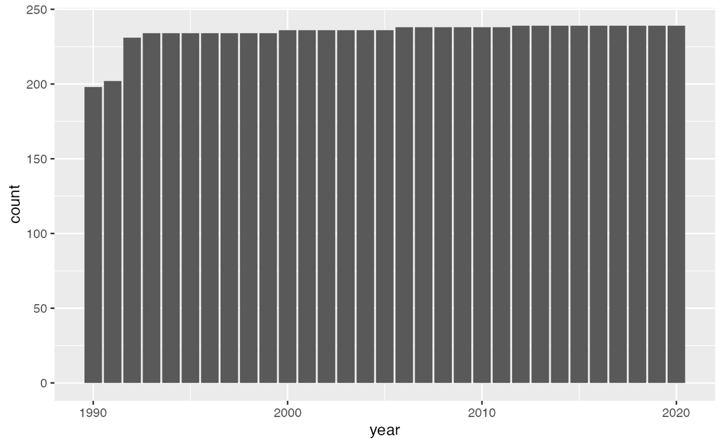

```r
df_w6eda |> drop_na(co2pcap, forest) |>
  ggplot(aes(year)) + geom_bar()
```

### 国と地域

country には、国と地域両方が入っています。地域の iso2c は以下のものです。

```r
REGION <- c("1A", "1W", "4E", "7E", "8S", "B8", "EU", "F1", "OE", "S1",
"S2", "S3", "S4", "T2", "T3", "T4", "T5", "T6", "T7", "V1", "V2",
"V3", "V4", "XC", "XD", "XE", "XF", "XG", "XH", "XI", "XJ", "XL",
"XM", "XN", "XO", "XP", "XQ", "XT", "XU", "XY", "Z4", "Z7", "ZF",
"ZG", "ZH", "ZI", "ZJ", "ZQ", "ZT")
```

#### 地域のリストを表示

```r
df_w6eda |> filter(iso2c %in% REGION) |> distinct(country, iso2c)
```

| country | iso2c |
| --- | --- |
| Africa Eastern and Southern | ZH |
| Africa Western and Central | ZI |
| Arab World | 1A |
| Caribbean small states | S3 |
| Central Europe and the Baltics | B8 |
| Early-demographic dividend | V2 |
| East Asia & Pacific | Z4 |
| East Asia & Pacific (excluding high income) | 4E |
| East Asia & Pacific (IDA & IBRD countries) | T4 |
| Euro area | XC |

[output cut: 39 more lines]

#### 国名とその地域・所得レベルを表示

```r
df_w6eda |> filter(!(iso2c %in% REGION)) |> distinct(country, iso2c, region, income)
```

| country | iso2c | region | income |
| --- | --- | --- | --- |
| Afghanistan | AF | South Asia | Low income |
| Albania | AL | Europe & Central Asia | Upper middle income |
| Algeria | DZ | Middle East & North Africa | Lower middle income |
| American Samoa | AS | East Asia & Pacific | Upper middle income |
| Andorra | AD | Europe & Central Asia | High income |
| Angola | AO | Sub-Saharan Africa | Lower middle income |
| Antigua and Barbuda | AG | Latin America & Caribbean | High income |
| Argentina | AR | Latin America & Caribbean | Upper middle income |
| Armenia | AM | Europe & Central Asia | Upper middle income |
| Aruba | AW | Latin America & Caribbean | High income |

[output cut: 207 more lines]

### 分析する国のリスト

BRICS を選択することにます。

```r
BRICS <- c("Brazil", "Russian Federation", "India", "China", "South Africa")
```

### a. 日本

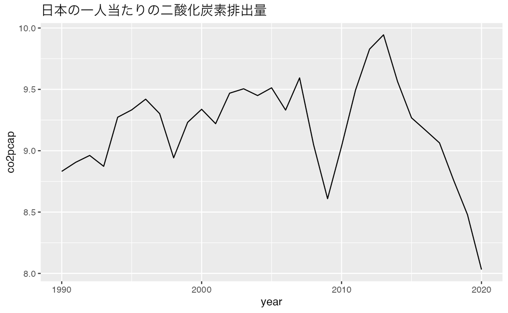

```r
df_w6 |> drop_na(co2pcap) |> filter(country == "Japan") |>
  ggplot(aes(year, co2pcap)) + geom_line() +
  labs(title = "日本の一人当たりの二酸化炭素排出量")
```

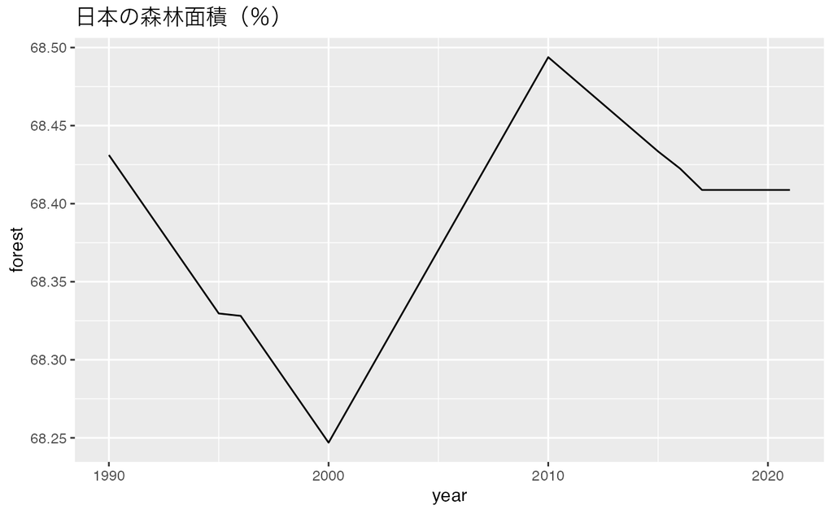

```r
df_w6 |> drop_na(forest) |> filter(country == "Japan") |>
  ggplot(aes(year, forest)) + geom_line() +
  labs(title = "日本の森林面積（％）")
```

### b. 選択した国・地域

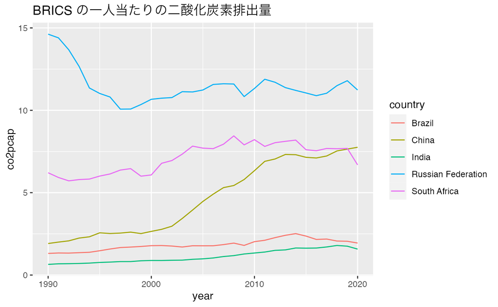

```r
df_w6 |> drop_na(co2pcap) |> filter(country %in% BRICS) |>
  ggplot(aes(year, co2pcap, col = country)) + geom_line() +
  labs(title = "BRICS の一人当たりの二酸化炭素排出量")
```

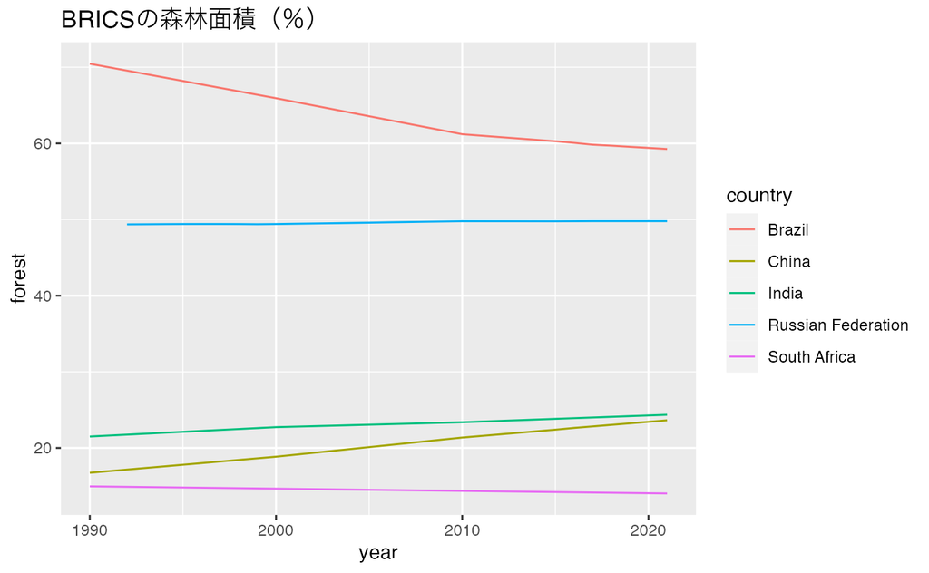

```r
df_w6 |> drop_na(forest) |> filter(country %in% BRICS) |>
  ggplot(aes(year, forest, col = country)) + geom_line() +
  labs(title = "BRICSの森林面積（％）")
```

### 二つのデータの散布図

必要に応じて log10 スケール

#### a. すべての値の散布図

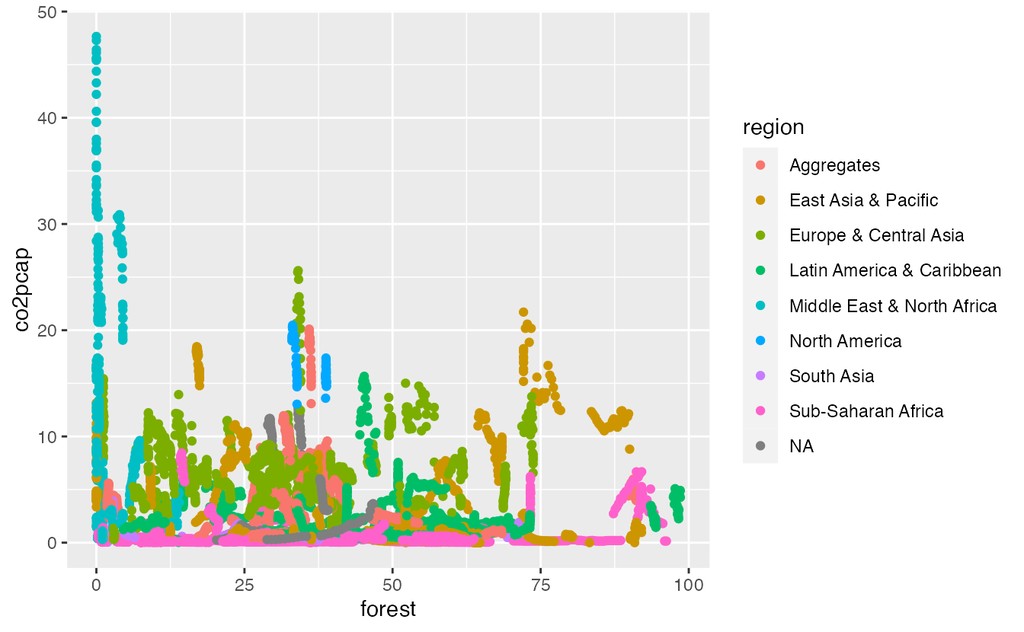

```r
df_w6 |> ggplot(aes(forest, co2pcap, col = region)) + geom_point()
```

#### b. NA ではない値の散布図、近似（回帰）直線を表示

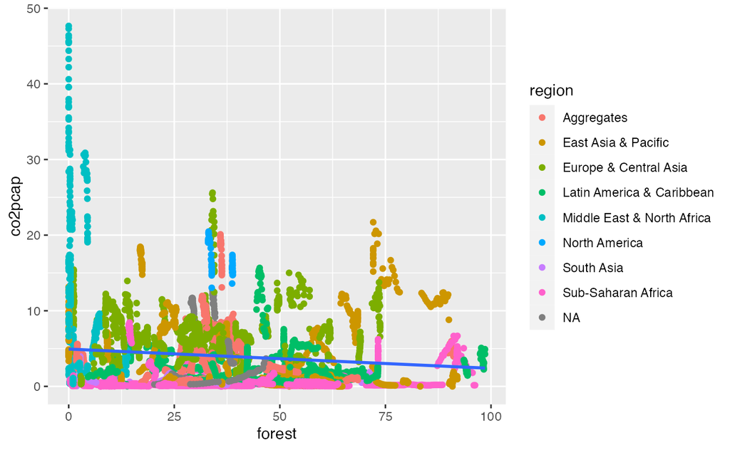

```r
df_w6 |> drop_na(co2pcap, forest) |>
  ggplot(aes(forest, co2pcap)) + geom_point(aes(col = region)) +
  geom_smooth(formula = 'y~x', method = "lm", se = FALSE)
```

#### c. 地域を除き国のみの散布図、近似（回帰）直線を表示

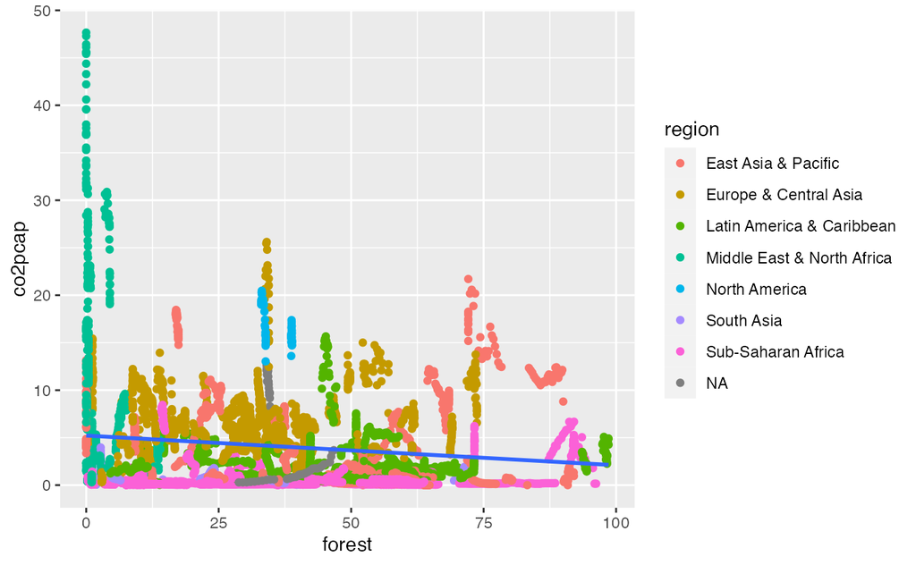

```r
df_w6 |> filter(!(iso2c %in% REGION)) |> drop_na(co2pcap, forest) |>
  ggplot(aes(forest, co2pcap)) + geom_point(aes(col = region)) +
  geom_smooth(formula = 'y~x', method = "lm", se = FALSE)
```

#### d. 最近の年を選択し、地域を除き国のもの散布図、近似（回帰）直線を表示

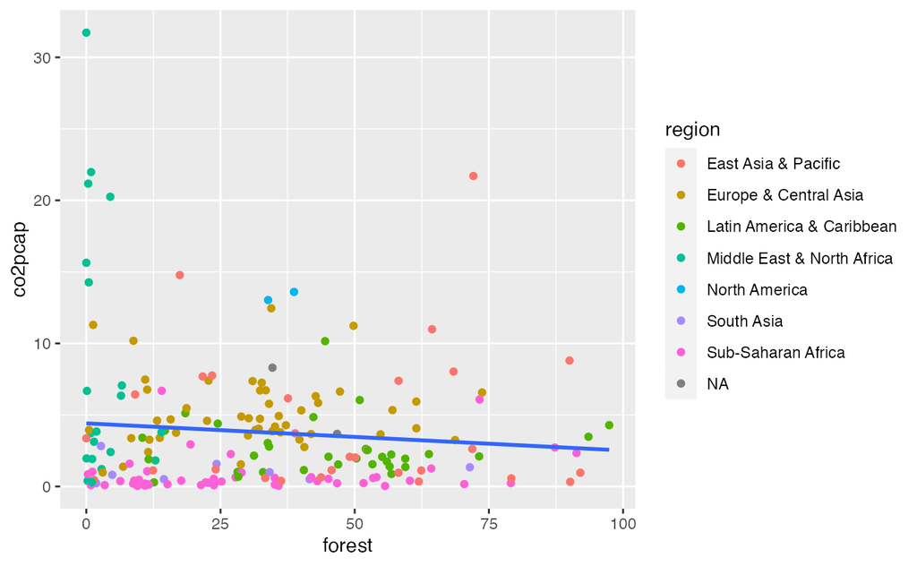

```r
df_w6 |> filter(!(iso2c %in% REGION)) |> filter(year == 2020) |> drop_na(co2pcap, forest) |>
  ggplot(aes(forest, co2pcap)) + geom_point(aes(col = region)) +
  geom_smooth(formula = 'y~x', method = "lm", se = FALSE)
```

**気づいたこと・疑問**

```r
df_w6 |> filter(!(iso2c %in% REGION)) |> filter(year == 2020) |> drop_na(co2pcap, forest) |>
  select(co2pcap, forest) |> cor()
```

```
            co2pcap      forest
co2pcap  1.00000000 -0.09914706
forest  -0.09914706  1.00000000
```

### 参考

```r
df_w6 |> filter(!(iso2c %in% REGION)) |> filter(year == 2020) |> drop_na(co2pcap, forest) |>
  select(co2pcap, forest) |> lm(co2pcap ~ forest, data = _) |> summary()
```

- Residuals: 直線よりどのぐらい大き値や小さい値があるか
- Coefficients: Estimate の (Intercept) は直線の y-切片、forest は、傾き
- Residual Standard Error: 直線からこの値の幅の間に、おおよそ 2/3 程度（68.2%）の点が入っている
- Multiple R-squared: 直線がどの程度近似しているか、0 と 1 の間で、相関係数の二乗
- p-value: かなり小さいと（たとえば 0.01 未満）相関が正か負かがほぼ確実といえる

[output not shown]

### 演習の内容と課題

基本的には、PositCloud（https://posit.cloud/）を使って実習

## 参考文献

1. 「みんなのデータサイエンス - Data Science for All」[[はじめてのデータサイエンス](https://icu-hsuzuki.github.io/ds4aj/first-example.html#first-example)]
   - 導入として、GDP（国内総生産）のデータを使って説明しています。
2. Posit Recipes（旧 Posit Primers）: The Basics 対話型の演習サイトの最初 [[Link](https://posit.cloud/learn/recipes)]
3. Posit Cheat Sheet. 早見表です。印刷して使うために、PDF も提供しています。[[Site Link](https://rstudio.github.io/cheatsheets/)]
4. DataCamp Cheat Sheet: Tidyverse for Biginners. データサイエンスの教育をしている会社の早見表の一つです。基本が簡単にまとまっています。[[Link](https://images.datacamp.com/image/upload/v1676302697/Marketing/Blog/Tidyverse_Cheat_Sheet.pdf)]